# pandas_george_15

### Python Pandas Tutorial - Part 15

#### Plotting - matplotlib

[Source: G. McIntire et. al](https://www.learndatasci.com/tutorials/python-pandas-tutorial-complete-introduction-for-beginners/)  
The code cells below comes largely from McIntire's tutorial, but sometimes they include my code.  
The comments below are a combination of notes in McIntire's tutorial and my comments.

**Imports**

```python
import pandas as pd
import matplotlib.pyplot as plt
```

**Read the IMDB movie data and clean up two column names**

```python
movies_df = pd.read_csv("IMDB-Movie-Data.csv", index_col="Title")
movies_df.columns = ['rank', 'genre', 'description', 'director', 'actors', 'year', 'runtime',
                     'rating', 'votes', 'revenue_millions', 'metascore']
```

**matplolib**  
Another great thing about pandas is that it integrates with Matplotlib, so you get the ability to plot directly off DataFrames and Series.  
If you don't have matplotlib installed then use: pip install matplotlib.

```python
# set font and plot size to be larger
plt.rcParams.update({'font.size': 20, 'figure.figsize': (10, 8)})
```

**Which type of plot to use**  
For categorical variables utilize Bar Charts* and Boxplots.

For continuous variables utilize Histograms, Scatterplots, Line graphs, and Boxplots.

**Create a scatter plot**  
What's with the semicolon?  
It's not a syntax error, just a way to hide the <matplotlib.axes._subplots.AxesSubplot at 0x26613b5cc18> output when plotting in Jupyter notebooks.

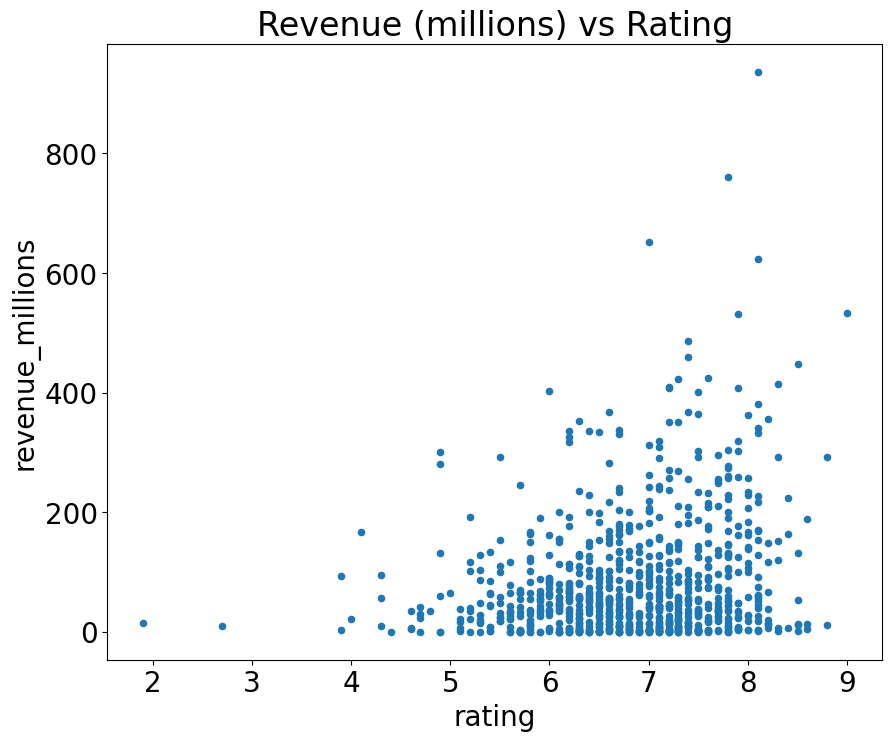

```python
movies_df.plot(kind='scatter', x='rating', y='revenue_millions', title='Revenue (millions) vs Rating');
```

**Create a simple Histogram**  
This Histogram is based on a single column, we can call plot on a column:

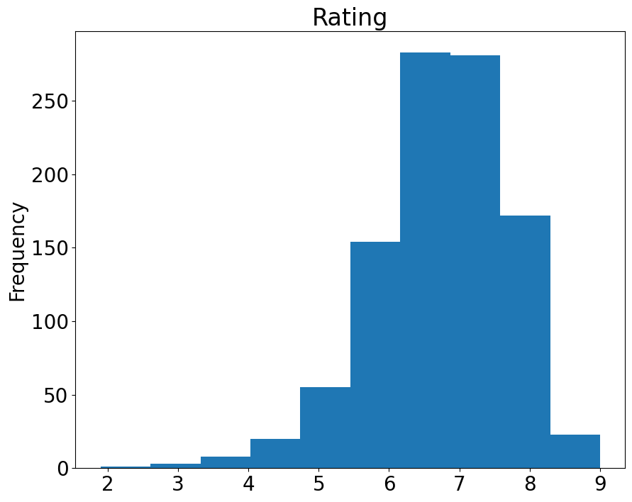

```python
movies_df['rating'].plot(kind='hist', title='Rating');
```

**Describe**  
Recall what the describe() function does.

```python
movies_df['rating'].describe()
```

```
count    1000.000000
mean        6.723200
std         0.945429
min         1.900000
25%         6.200000
50%         6.800000
75%         7.400000
max         9.000000
Name: rating, dtype: float64
```

**Boxplot**  
A Boxplot is a graphical representation of the interquartile range.

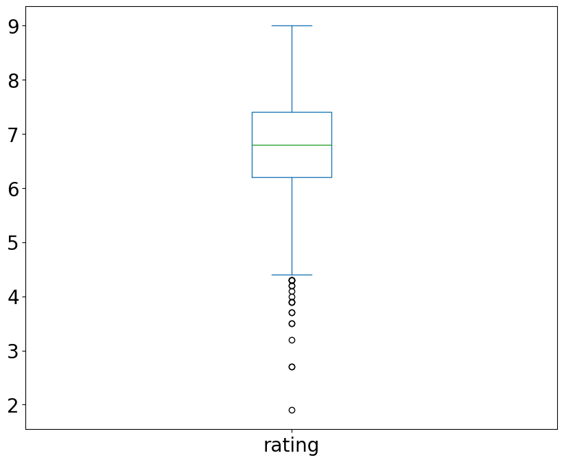

```python
movies_df['rating'].plot(kind="box");
```

**Recreate the rating_category columns**

```python
movies_df["rating_category"] = movies_df["rating"].apply(lambda x: 'good' if x >= 8.0 else 'bad')
```

**Boxplot**  
By combining categorical and continuous data, we can create a Boxplot of revenue that is grouped by the Rating Category we created above:

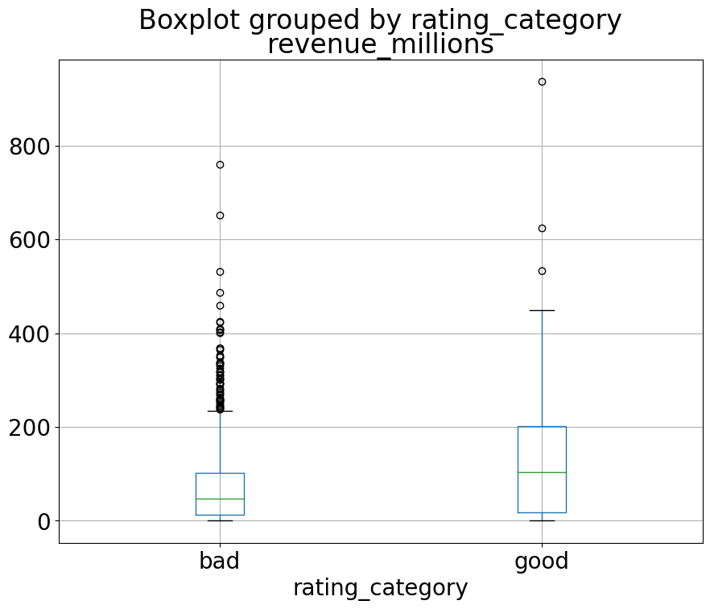

```python
movies_df.boxplot(column='revenue_millions', by='rating_category');
```